# 21. Notes on ‘Ch 23. Dirichlet process models’

> These are just notes on a single chapter of *BDA3* that were not part of the course.

## Chapter 23. Dirichlet process models

- **Dirichlet process**: an infinite-dimensional generalization of the Dirichlet distribution
  - used as a prior on unknown distributions
  - can extend finite component mixture models to infinite mixture models

### 23.1 Bayesian histograms

- the histogram as a simple form of density estimation
  - demonstrate a flexible parametric version that motivates the non-parametric in the following section
- prespecified knots: $\xi = (\xi_0, \dots, \xi_k)$ with $\xi_{n-1} < \xi_n$
- probability model for the density (a histogram):
  - where $\pi = (\pi_1, \dots, \pi_k)$ is an unknown probability vector

$$f(y) = \sum_{h=1}^k 1_{\xi_{h-1} < y \le \xi_h} \frac{\pi_h}{(\xi_h -
\xi_{h-1})}$$

- prior for the probabilities $\pi$ as a Dirichlet distribution:

$$p(\pi|a) = \frac{\Gamma(\sum_{h=1}^k a_h)}{\prod_{h=1}^k \Gamma(a_h)}
\prod_{h=1}^k \pi _h^{a_h - 1}$$

- replace the hyperparameter vector: $a = \alpha \pi_0$ where $\pi_0$ is:

$$\text{E}(\pi|a) = \pi_0 = \left( \frac{a_1}{\sum_h a_h}, \dots,
\frac{a_k}{\sum_h a_h} \right)$$

- the posterior for $\pi$ becomes:
  - where $n_i$ is the number of observations $y$ in the $i$th bin

$$p(\pi | y) \propto \prod_{h=1}^k \pi_h^{a_h + n_h - 1} =
\text{Dirichlet}(a_1 + n_1, \dots, a_k + n_k)$$

- this histogram estimator does well but is sensitive to the specification of the knots

### 23.2 Dirichlet process prior distributions

#### Definition and basic properties

- goal is to not need to prespecify the bins of the histogram
- let:
  - $\Omega$: sample space
  - $B_1, \dots, B_k$: measure subsets of $\Omega$
- if $\Omega = \Re$, then $B_1, \dots, B_k$ are non-overlapping intervals that partition the real line into a finite number of bins
- $P$: unknown probability measure of $(\Omega, \mathcal{B})$
  - $\mathcal{B}$: “collection of all possible subsets of the sample space $\Omega$”
  - $P$ assigns probabilities to the subsets $\mathcal{B}$
  - probability for a set of bins $B_1, \dots, B_k$ partitioning $\Omega$:

$$P(B_1), \dots, P(B_k) = \left( \int_{B_1} f(y) dy, \dots, \int_{B_k}
f(y) dy \right)$$

$$P(B_1), \dots, P(B_k) \sim \text{Dirichlet}(\alpha P_0(B_1), \dots,
\alpha P_0(B_k))
\tag{1}$$

- difference with previous Bayesian histogram: only specifies that bin $B_k$ is assigned probability $P(B_k)$ and not how probability mass is distributed across the bin $B_k$
  - thus, for a fixed set s of bins, this equation does not full specify the prior for $P$
  - need to eliminate the sensitivity to the choice of bins by assuming the prior holds for all possible partitions $B_1, \dots, B_k$ for all $k$
    - then it is a fully specified prior for $P$
- “must exist a random probability measure $P$ such that the probabilities assigned to any measurable partition $B_1, \dots, B_k$ by $P$ is $\text{Dirichlet}(\alpha P_0(B_1), \dots, \alpha P_0(B_k))$”
  - the resulting $P$ is a Dirichlet process:
    - $P \sim \text{DP}(\alpha P_0)$
    - $\alpha > 0$: a scalar precision parameter
    - $P_0$: baseline probability measure also on $(\Omega, \mathcal{B})$
- implications of DP:
  - the marginal random probability assigned to any subset $B$ is a beta distribution
    - $P(B) \sim \text{Beta}(\alpha PP_0(B), \alpha (1-P_0(B)))$ for all $B \in \mathcal{B}$
  - the prior for $P$ is centered on $P_0$: $E(P(B)) = P_0(B)$
  - $\alpha$ controls variance
    - $\text{var}(P(B)) = \frac{P_0(B)(1 - P_0(B))}{1 + \alpha}$
- get posterior for $P$:
  - let $y_i \stackrel{iid}{\sim} P$ fir $i = 1, \dots, n$
  - $P \sim \text{DP}(\alpha P_0)$
    - $P$ denotes the probability measure *and* its corresponding distribution
  - from (1), for any partition $B_1, \dots, B_k$:

$$p(B_1), \dots, P(B_k) | y_1, \dots, y_k \sim
\text{Dirichlet} \left(
\alpha P_0(B_1) + \sum_{i=1}^n 1_{y_i \in B_1}, \dots, \alpha
P_0(B_k) + \sum_{i=1}^n 1_{y_i \in B_k}
\right)$$

- this can be converted to the following:

$$P | y_1, \dots, y_n \sim \text{DP} \left( \alpha P_0 \sum_i \delta_{y+i}
\right)$$

- finally, the posterior expectation of $P$:

$$\text{E}(P(B) | y^n) =
\left(\frac{\alpha}{\alpha + n} \right) P_0(B) +
\left(\frac{n}{\alpha + n} \right) \sum_{i=1}^n \frac{1}{n}
\delta_{y_i}
\tag{2}$$

- DP is a model similar to a random histogram but without dependence on the bins
- cons of a DP prior:
  - lack of smoothness
  - induces negative correlation between $P(B_1)$ and $P(B_2)$ for any two disjoint bins with no account for the distance between them
  - realizations from the DP are discrete distributions
    - with $P \sim \text{DP}(\alpha P_0)$, $P$ is atomic and have nonzero weights only on a set of atoms, not a continuous density on the real line

#### Stick-breaking construction

- more intuitive understanding of DP
- induce $P \sim \text{DP}(\alpha P_0)$ by letting:

$$\begin{aligned}
P(\cdot) &= \sum_{h=1}^{\infty} \pi_h \delta_{\theta_h}(\cdot) \\
\pi_h &= V_h \prod_{l<h} (1 - V_i) \\
V_h &\sim \text{Beta}(1, \alpha) \\
\theta_h &\sim P_0
\end{aligned}$$

- where:
  - $P_0$: base distribution
  - $\delta_\theta$: degenerate distribution with all mass at $\theta$
  - $(\theta_h)_{h=1}^{\infty}$: the *atoms* generated independently by from $P_0$
    - the atoms are generated by the *stick-breaking process*
    - this ensures the weights sum to 1
  - $\pi_h$: probability mass at atom $\theta_h$
- the *stick-breaking process*:
  - start with a stick of length 1
    - represents the total probability allocated to all the atoms
  - break off a random piece of length $V_1$ determined by a draw from $\text{Beta}(1, \alpha)$
  - set $\pi_1 = V_1$ as the probability weight to the randomly generated first atom $\theta_1 \sim P_0$
  - break off another piece of the remaining stick (now length $1-V_1$): $V_2 \sim \text{Beta}(1, \alpha)$
  - set $\pi_2 = V_2(1-V_1)$ as the probability weight to the next atom $\theta_2 \sim P_0$
  - repeat until the stick is fully used
- implications:
  - during the process, the stick get shorter, so lengths allocated to later indexed atoms decrease stochastically
  - rate of decrease of stick length depends on $\alpha$
    - $\alpha$ near 0 lead to high weights early on
- below are realizations of the stick breaking process
  - set $P_0$ as a standard normal distribution and vary $\alpha$

```r
stick_breaking_process <- function(alpha, n = 1000) {
  theta <- rnorm(n, 0, 1) # P0 = standard normal
  vs <- rbeta(n, 1, alpha)
  pi <- rep(0, n)
  pi[1] <- vs[1]
  stick <- 1.0 - vs[1]
  for (h in 2:n) {
    pi[h] <- vs[h] * stick
    stick <- stick - pi[h]
  }
  return(list(theta = theta, pi = pi))
}

dp_realization <- stick_breaking_process(10)
sum(dp_realization$pi)
```

```
#> [1] 1
```

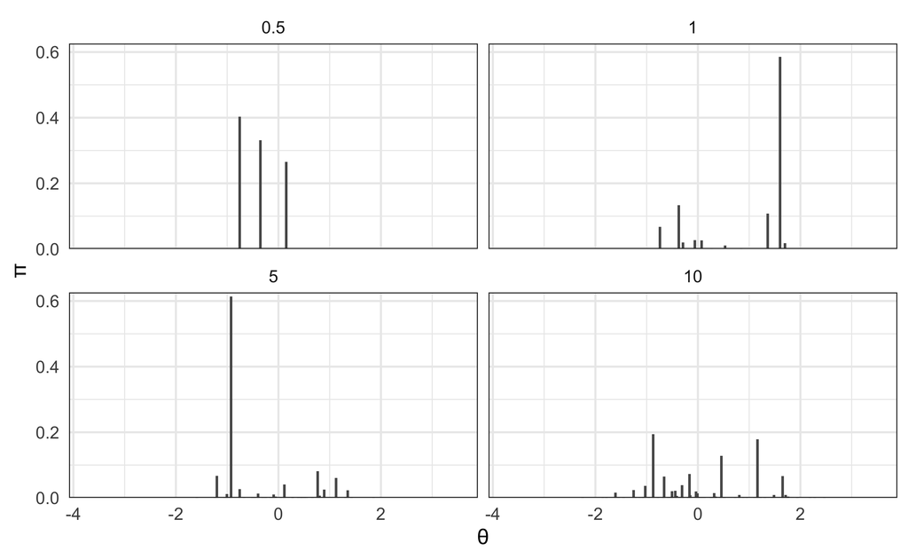

```r
set.seed(549)

tibble(alpha = c(0.5, 1, 5, 10)) %>%
  mutate(
    dp = purrr::map(alpha, stick_breaking_process, n = 1000),
    theta = purrr::map(dp, ~ .x$theta),
    pi = purrr::map(dp, ~ .x$pi)
  ) %>%
  select(-dp) %>%
  unnest(c(theta, pi)) %>%
  ggplot(aes(x = theta, y = pi)) +
  facet_wrap(vars(alpha), nrow = 2, scales = "fixed") +
  geom_col(width = 0.05) +
  scale_x_continuous(expand = expansion(c(0.02, 0.02))) +
  scale_y_continuous(expand = expansion(c(0, 0.02))) +
  labs(x = "\u03B8", y = "\u03C0")
```

### 23.3 Dirichlet process mixtures

#### Specification and Polya urns

- **“the DP is more appropriately used as a prior for an unknown mixture of distributions”** (pg 549)
- in the case of density estimation, a general kernel mixture model can be specified as (3)
  - $\mathcal{K}(\cdot | \theta)$: a kernel
  - $\theta$: location and possibly scale parameters
  - $P$: “mixing measure”

$$f(y|P) = \int \mathcal{K}(y|\theta) d P(\theta)
\tag{3}$$

- treating $P$ as discrete results in a finite mixture model
- setting a prior on $P$ creates an infinite mixture model
  - prior: $P \sim \pi_\mathcal{P}$
    - $\mathcal{P}$: space of all probability measures on $(\Omega, \mathcal{B})$
    - $\pi_\mathcal{P}$: the prior over the space defined by $\mathcal{P}$
- if set $\pi_\mathcal{P}$ as a DP prior, results in a DP mixture model
  - from (2) and (3), a DP prior on $P$ results in (4)
  - where:
    - $\pi = \sim \text{stick}(\alpha)$ denotes that the probability weights are from the stick-breaking process with parameter $\alpha$
    - $\theta_h \sim P_0$ independently for each $h=1, \dots, \infty$

$$f(y) = \sum_{h=1}^\infty \pi_h \mathcal{K}(y | \theta_h^*)
\tag{4}$$

- equation (4) resembles a finite mixture model except the number of mixture components in set to infinity
  - does not mean there will be infinite number of components
  - instead the model is just flexible to add more mixture components if necessary
- consider the following specification
  - issue of how to conduct posterior computation with a DP mixture (DPM) because $P$ has infinitely many parameters

$$y_i \sim \mathcal{K}(\theta_i) \text{,} \quad
\theta_i \sim P \text{,} \quad
P \sim \text{DP}(\alpha P_0)$$

- can marginalize out $P$ to get an induced prior on the subject-specific parameters $\theta^n = (\theta_1, \dots, \theta_n)$
- results in the *Polya urn* predictive rule:

$$p(\theta_i | \theta_1, \dots, \theta_{i-1}) \sim \left(
\frac{\alpha}{\alpha + i -1} \right) P_0(\theta_i) +
\sum_{j=1}^{i-1} \left( \frac{1}{\alpha + i - 1} \right)
\delta_{\theta_j}
\tag{5}$$

- *Chinese restaurant process* as a metaphor for the Polya urn predictive rule (5):
  - consider a restaurant with infinitely many tables
  - the first customers sits at a table with dish $\theta_1^*$
  - the second customer sits at the first table with probability $\frac{1}{1+\alpha}$ or a new table with probability $\frac{\alpha}{1+\alpha}$
  - repeat this process for the $i$th customer:
    - sit at an occupied table with probability $\frac{c_j}{1 - i + \alpha}$ where $c_j$ is the number of customers already at the table -sit at a new table with probability $\frac{\alpha}{n-i+\alpha}$
  - interpretation:
  - each table represents a cluster of subjects
  - the number of clusters depends on the number of subjects
  - makes sense to have the possibility of more clusters with more subjects (instead of a fixed number of clusters as in a finite mixture model)
- there is a description of the sampling process for the posterior of $\theta_i | \theta_{-i}$

#### Hyperprior distribution

- $\alpha$: the DP precision parameter
  - plays a role in controlling the prior on the number of clusters
  - small, fixed $\alpha$ favors allocation to few clusters (relative to sample size)
    - if $\alpha=1$, the prior indicates that two randomly selected subjects have a 50/50 chance of belonging to the same cluster
  - alternatively can set a hyperprior on $\alpha$ and let the data inform the value
    - common to use a Gamma distribution: $\Gamma(a_\alpha, b_\alpha)$
    - authors indicate that setting a hyperprior on $\alpha$ tends to work well in practice
- $P_0$: base probability for the DP
  - can think of $P_0$ as setting the prior for the cluster locations
  - can put hyperpriors on $P_0$ parameters

### 23.4 Beyond density estimation

#### Nonparametric residual distributions

- “The real attraction of Dirichlet process mixture (DPM) models is that they can be used much more broadly for relaxing parametric assumptions in hierarchical models.” (pg 557)
- consider the linear regression with a nonparametric error distribution (6)
  - $X_i = (X_{i1}, \dots, X_{ip})$: vector of predictors
  - $\epsilon_i$: error term with distribution $f$

$$y_i = X_i \beta + \epsilon_i \text{,} \quad \epsilon_i \sim f
\tag{6}$$

- can relax the assumption that $f$ has parametric form

$$\epsilon_i \sim N(0, \phi_i^{-1}) \text{,} \quad \phi \sim P \text{,}
\quad P \sim \text{DP}(\alpha P_0)$$

#### Nonparametric models for parameters that vary by group

- consider hierarchical linear models with varying coefficients
  - can account for uncertainty about the distribution of coefficients by placing a DP or DPM priors on them
  - where:
    - $y_i = (y_{i1}, \dots, y_{in_i})$: repeated measurements for item $i$
    - $\mu_i$: subject-specific mean
    - $\epsilon_{ij}$: observation specific residual

$$y_{ij} = \mu_i + \epsilon_{ij} \text{,} \quad \mu_i \sim f \text{,}
\quad \epsilon_{ij} \sim g
\tag{7}$$

- typically for (7):
  - $f \equiv N(\mu, \phi^{-1})$
  - $g \equiv N(0, \sigma^2)$
- can let more flexibility in characterizing variability among subjects:
  - $\mu_i \sim P \text{,} \quad P \sim \text{DP}(\alpha P_0)$
  - the DP prior induces a *latent class* model
    - the subjects are grouped into an unknown number of clusters (8)
    - $S_i \in \{1, \dots, \infty\}$: latent class index
    - $\pi_h$: probability of allocation to latent class $h$

$$\mu_i = \mu^*_{S_i} \text{,} \quad \Pr(S_i = h) = \pi_h \text{,} \quad h
= 1, 2, \dots
\tag{8}$$

> There is more to this chapter, but it is currently beyond my understanding. I hope to return to this chapter later with a better understanding of Dirichlet processes in the future.